# Integración Multiómica: MOFA+ y DIABLO

María Sánchez Vivo

2026-05-24

# **Introducción**

El script implementa un **análisis multi-ómico completo** que integra datos clínicos, metabolómicos y de microbiota mediante un flujo que combina preparación y limpieza de datos, alineación de muestras y construcción de matrices comparables entre capas biológicas. A partir de esta base común, se aplican **modelos de integración no supervisada (MOFA+)** para identificar factores latentes compartidos y explorar la estructura global de los datos, y posteriormente **modelos supervisados (DIABLO)** para discriminar grupos clínicos e identificar variables biomarcadoras relevantes. El proceso se complementa con evaluaciones estadísticas, validación cruzada y visualizaciones que permiten interpretar tanto las asociaciones entre ómicas como su relación con el diagnóstico clínico.

## Configuración del entorno y carga de librerías

En este apartado se establece la ruta de Python para asegurar la compatibilidad con *reticulate* y librerías como *mofapy2*, y se cargan los paquetes necesarios para análisis multiómico, visualización y modelado estadístico. Finalmente, se importan los conjuntos de datos principales de metabolitos, microbiota, taxonomía y variables clínicas.

```r
# IMPORTANTE: ejecutar ANTES de cargar cualquier librería para que "reticulate"
# detecte el Python correcto con "mofapy2"
Sys.setenv(RETICULATE_PYTHON = "/usr/bin/python3")
Sys.setenv(PYTHONPATH = "/home/alumno23/.local/lib/python3.8/site-packages")

set.seed(123)

library(reticulate)
use_python("/usr/bin/python3", required = TRUE)
py_run_string("import sys; sys.path.insert(0, '/home/alumno23/.local/lib/python3.8/site-packages')")

library(mixOmics)
library(MOFA2)
library(mia)
library(tidyverse)
library(ggpubr)
library(ggrepel)
library(ComplexHeatmap)
library(circlize)
library(RColorBrewer)
library(TreeSummarizedExperiment)
library(SummarizedExperiment)
library(BiocParallel)

param_paralelo <- MulticoreParam(workers = 8)

datos_metabolitos     <- readRDS("metabolitos.rds")
datos_metataxonomicos <- readRDS("tax.rds")
datos_clinicos        <- readRDS("covs.rds")
datos_abundancia_16S  <- readRDS("metagen.rds")
```

## Limpieza inicial y preparación de datos clínicos y ómicos

Después, se realiza la depuración de las variables clínicas eliminando columnas no informativas y se integran con los datos de metabolitos. A partir de aquí se identifican variables numéricas y categóricas relevantes, filtrando aquellas con variabilidad suficiente. En paralelo, se preparan los datos de microbiota y taxonomía, alineando muestras y taxones comunes para construir matrices consistentes entre ómicas.

```r
datos_clinicos_limpios <- datos_clinicos %>%
  as.data.frame() %>%
  dplyr::select(-ends_with("_0"))

datos_clinicos_metabolomicos <- merge(
  datos_clinicos_limpios,
  datos_metabolitos,
  by = "Sample"
)

nombres_metabolitos <- names(datos_metabolitos)[
  names(datos_metabolitos) != "Sample"
]

vars_id <- c("Sample", "diagnostico_principal")

# Variables clínicas numéricas
vars_num_clin <- datos_clinicos_metabolomicos %>%
  dplyr::select(-all_of(vars_id), -all_of(nombres_metabolitos)) %>%
  dplyr::select(where(is.numeric)) %>%
  dplyr::select(where(~ n_distinct(., na.rm = TRUE) >= 2)) %>%
  names()

# Variables clínicas categóricas (sin constantes)
vars_cat_clin <- datos_clinicos_metabolomicos %>%
  dplyr::select(-all_of(vars_id), -all_of(nombres_metabolitos)) %>%
  dplyr::select(where(~ is.factor(.) | is.character(.))) %>%
  dplyr::select(where(~ n_distinct(., na.rm = TRUE) >= 2)) %>%
  names()

cat("Variables clínicas numéricas:", length(vars_num_clin), "\n")
```

```
## Variables clínicas numéricas: 34
```

```r
cat("Variables clínicas categóricas:", length(vars_cat_clin), "\n")
```

```
## Variables clínicas categóricas: 84
```

```r
paleta_dx <- c(
  "CBP"     = "#E41A1C",
  "Healthy" = "#4DAF4A",
  "HAI"     = "#377EB8",
  "VHC"     = "#FF7F00"
)
```

## Filtrado y estructuración de la microbiota

En este punto se transforma la tabla de abundancias microbianas en un objeto coherente a nivel taxonómico mediante *TreeSummarizedExperiment*. Posteriormente se agregan los datos a nivel de género, se convierten a abundancias relativas y se filtran los taxones menos informativos en función de su prevalencia y abundancia media, reduciendo ruido y mejorando la estabilidad de los análisis posteriores.

```r
# PREPARACION MICROBIOTA

counts_prepared <- datos_abundancia_16S %>%
  tibble::column_to_rownames("Sample") %>%
  t() %>%
  as.matrix()
colnames(counts_prepared) <- trimws(colnames(counts_prepared))

datos_clinicos_mia <- as.data.frame(datos_clinicos)
rownames(datos_clinicos_mia) <- trimws(as.character(datos_clinicos_mia$Sample))

tax_prepared <- datos_metataxonomicos %>%
  as.data.frame() %>%
  as.matrix()
rownames(tax_prepared) <- trimws(rownames(tax_prepared))

comun_muestras <- intersect(colnames(counts_prepared), rownames(datos_clinicos_mia))
counts_filtrado <- counts_prepared[, comun_muestras]
clinicos_final  <- datos_clinicos_mia[comun_muestras, ]

comun_taxones <- intersect(rownames(counts_filtrado), rownames(tax_prepared))
counts_final  <- counts_filtrado[comun_taxones, ]
tax_final     <- tax_prepared[comun_taxones, ]

tse <- TreeSummarizedExperiment(
  assays  = list(counts = as.matrix(counts_final)),
  colData = DataFrame(clinicos_final),
  rowData = DataFrame(tax_final)
)

tse_genus <- agglomerateByRank(tse, rank = "Genus")
tse_genus <- tse_genus[rowData(tse_genus)$Genus != "", ]

tse_genus_rel <- transformAssay(tse_genus, method = "relabundance")

prevalencia <- rowMeans(assay(tse_genus_rel, "relabundance") > 0)
abund_media <- rowMeans(assay(tse_genus_rel, "relabundance"))
generos_filt <- names(which(prevalencia >= 0.2 & abund_media >= 0.001))

cat("Número generos retenidos:", length(generos_filt), "\n")
```

```
## Número generos retenidos: 35
```

```r
mat_bact_raw <- t(assay(tse_genus[generos_filt, ], "counts"))
```

Se obtiene un resultado de **35 géneros retenidos**, es decir, 35 géneros bacterianos han pasado con éxito el filtro de calidad matemática.

## Alineación final de muestras y construcción de variables objetivo

Después, se identifican las muestras comunes entre clínicos, metabolitos y microbiota para garantizar la comparabilidad entre bloques. Se construye la variable de diagnóstico como factor ordenado, que será utilizada tanto en modelos supervisados como en la evaluación de la estructura biológica de los datos.

```r
# ALINEACION FINAL DE BLOQUES

muestras_comun <- Reduce(intersect, list(
  datos_clinicos_metabolomicos$Sample,
  rownames(mat_bact_raw)
))

cat("Muestras comunes:", length(muestras_comun), "\n")
```

```
## Muestras comunes: 46
```

```r
df_base <- datos_clinicos_metabolomicos %>%
  dplyr::filter(Sample %in% muestras_comun) %>%
  arrange(match(Sample, muestras_comun))

Y <- factor(
  df_base$diagnostico_principal,
  levels = c("Healthy", "VHC", "HAI", "CBP")
)
names(Y) <- df_base$Sample

print(table(Y))
```

```
## Y
## Healthy     VHC     HAI     CBP
##      12      14       8      12
```

# **Construcción de matrices multiómicas para análisis integrados**

En esta fase se generan las matrices finales para cada ómica. Los metabolitos se escalan, las variables clínicas se combinan (numéricas y categóricas codificadas) y también se estandarizan, mientras que la microbiota se transforma mediante CLR y posterior escalado. Además, se aplican filtros de varianza casi nula para eliminar variables redundantes y asegurar estabilidad en los modelos de integración.

```r
# CONSTRUCCION DE BLOQUES (escalados)
# Se incluyen variables clínicas categóricas codificadas como numéricas

# ── Metabolitos ───────────────────────────────────────────────────────────────
mat_met <- scale(as.matrix(df_base[, nombres_metabolitos]))
rownames(mat_met) <- df_base$Sample

# ── Clínica: numéricas + categóricas codificadas ──────────────────────────────
# Las categóricas se convierten a numérico (nivel del factor)
# Para variables binarias (0/1) esto es directo
# Para variables numéricas respeta el orden de los niveles
mat_cat_coded <- df_base %>%
  dplyr::select(all_of(vars_cat_clin)) %>%
  mutate(across(everything(), ~ as.numeric(as.factor(.)))) %>%
  as.matrix()
rownames(mat_cat_coded) <- df_base$Sample

# Combinar numéricas y categóricas en una sola matriz y escalar
mat_clin_completa <- cbind(
  as.matrix(df_base[, vars_num_clin]),
  mat_cat_coded
)
rownames(mat_clin_completa) <- df_base$Sample

mat_clin_completa_scaled <- scale(mat_clin_completa)

cat("Variables clínicas numéricas:", length(vars_num_clin), "\n")
```

```
## Variables clínicas numéricas: 34
```

```r
cat("Variables clínicas categóricas codificadas:", length(vars_cat_clin), "\n")
```

```
## Variables clínicas categóricas codificadas: 84
```

```r
cat("Total variables clínicas antes de filtro:", ncol(mat_clin_completa_scaled), "\n")
```

```
## Total variables clínicas antes de filtro: 118
```

```r
# Eliminar near-zero variance sobre la matriz completa (para DIABLO)
nzv_clin <- nearZeroVar(mat_clin_completa_scaled, freqCut = 19, uniqueCut = 10)
if (length(nzv_clin$Position) > 0) {
  cat("Variables eliminadas por varianza casi cero:",
      length(nzv_clin$Position), "\n")
  mat_clin <- mat_clin_completa_scaled[, -nzv_clin$Position, drop = FALSE]
} else {
  mat_clin <- mat_clin_completa_scaled
}
```

```
## Variables eliminadas por varianza casi cero: 24
```

```r
cat("Variables clínicas retenidas para DIABLO:", ncol(mat_clin), "\n")
```

```
## Variables clínicas retenidas para DIABLO: 94
```

```r
# Para MOFA+ usar mat_clin_completa_scaled (antes del filtro NZV)
# porque MOFA+ filtra internamente con filtro_ok (sd > 0)
mat_clin_mofa_preparada <- mat_clin_completa_scaled
rownames(mat_clin_mofa_preparada) <- df_base$Sample

# ── Microbiota: CLR + escalado ────────────────────────────────────────────────
mat_bact_ordenada <- mat_bact_raw[df_base$Sample, , drop = FALSE]
mat_bact_clr <- mixOmics::logratio.transfo(mat_bact_ordenada + 1, logratio = "CLR")
mat_bact <- scale(as.matrix(mat_bact_clr))
rownames(mat_bact) <- df_base$Sample

# Control de calidad
if (!identical(rownames(mat_met), rownames(mat_clin)) |
    !identical(rownames(mat_met), rownames(mat_bact))) {
  stop("ERROR: muestras desalineadas entre bloques")
}

cat("\nDimensiones finales:\n")
```

```
##
## Dimensiones finales:
```

```r
cat("Metabolitos:", nrow(mat_met), "x", ncol(mat_met), "\n")
```

```
## Metabolitos: 46 x 53
```

```r
cat("Clinica:    ", nrow(mat_clin), "x", ncol(mat_clin),
    "(num + cat codificadas, sin NZV)\n")
```

```
## Clinica:     46 x 94 (num + cat codificadas, sin NZV)
```

```r
cat("Microbiota: ", nrow(mat_bact), "x", ncol(mat_bact), "\n")
```

```
## Microbiota:  46 x 35
```

# **Preparación del modelo MOFA+ (integración NO supervisada)**

Después, se estructuran los datos en formato compatible con MOFA+, separando las tres vistas (metabolitos, microbiota y clínica). Se limpian los nombres de variables para evitar problemas de codificación y se define la configuración del modelo, incluyendo número de factores, parámetros de entrenamiento y opciones de escalado. Con esto se crea el objeto MOFA listo para entrenamiento.

```r
# PREPARAR MOFA+
# NOTA: para MOFA usamos mat_clin_mofa_preparada (numéricas + categóricas, antes de NZV)

mat_met_mofa  <- as.matrix(mat_met);               storage.mode(mat_met_mofa)  <- "double"
mat_bact_mofa <- as.matrix(mat_bact);              storage.mode(mat_bact_mofa) <- "double"
mat_clin_mofa <- as.matrix(mat_clin_mofa_preparada); storage.mode(mat_clin_mofa) <- "double"

filtro_ok <- function(x) {
  x <- x[apply(x, 1, function(v) all(is.finite(v))), , drop = FALSE]
  x <- x[apply(x, 1, sd) > 0, , drop = FALSE]
  x
}

mofa_data <- list(
  metabolitos = filtro_ok(t(mat_met_mofa)),
  microbiota  = filtro_ok(t(mat_bact_mofa)),
  clinica     = filtro_ok(t(mat_clin_mofa))
)

# Limpieza de caracteres Non-ASCII
mofa_data <- lapply(mofa_data, function(matriz) {
  # iconv transforma caracteres acentuados o especiales a ASCII aproximado (ó -> o, ñ -> n)
  nombres_limpios <- iconv(rownames(matriz), to = "ASCII//TRANSLIT")

  # Por seguridad, se elimina cualquier caracter extraño residual que no sea letra, nº o guión bajo
  nombres_limpios <- gsub("[^A-Za-z0-9_.-]", "_", nombres_limpios)

  rownames(matriz) <- nombres_limpios
  return(matriz)
})

cat("\nDimensiones MOFA (features x muestras):\n")
```

```
##
## Dimensiones MOFA (features x muestras):
```

```r
print(lapply(mofa_data, dim))
```

```
## $metabolitos
## [1] 53 46
##
## $microbiota
## [1] 35 46
##
## $clinica
## [1] 118  46
```

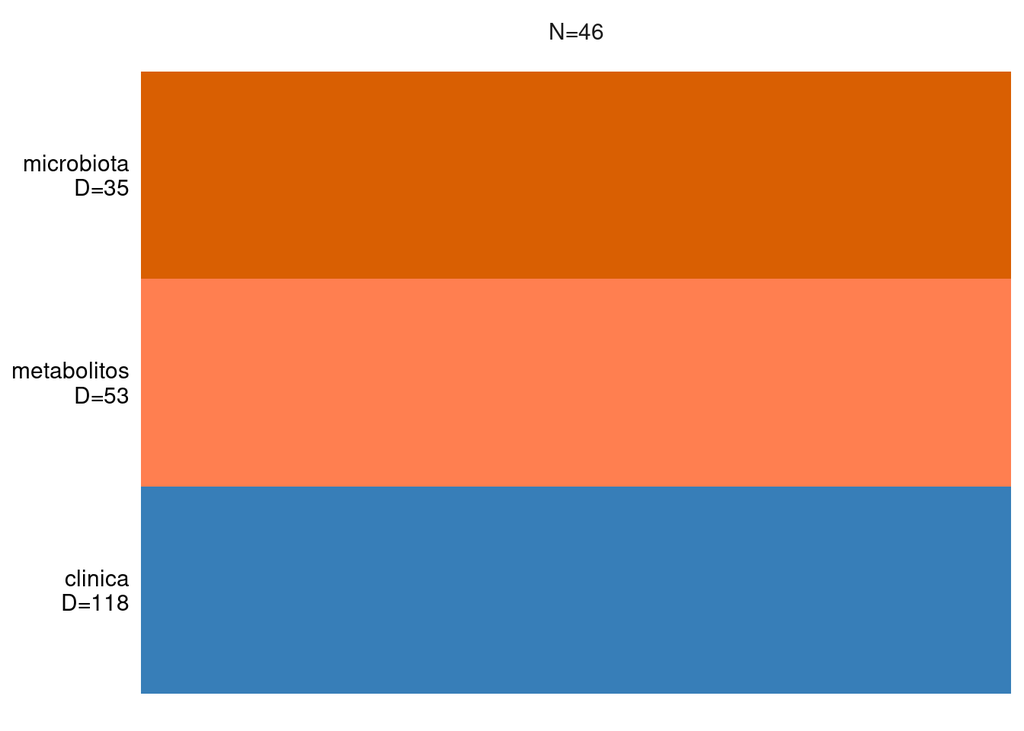

```r
mofa <- create_mofa(mofa_data)

plot_data_overview(mofa)
```

El gráfico resultante ilustra el diseño de entrada para el modelo ómico integrado (**MOFA**), confirmando una matriz completa y balanceada de **N = 46 muestras** compartidas a través de los tres niveles biológicos analizados. Cada bloque detalla el número de variables (D) consideradas: la capa **clínica** con 118 parámetros, la de **metabolitos** con 53 compuestos y la de **microbiota** con 35 géneros bacterianos. Esta estructura sin datos faltantes es la base ideal para que el algoritmo identifique los factores latentes que mejor explican la variabilidad compartida entre la clínica, el metaboloma y el microbioma.

## Configuración de MOFA+

```r
# CONFIGURACION MOFA+

model_opts <- get_default_model_options(mofa)
model_opts$num_factors <- 5          # Para capturar variablidad de los 4 grupos y aislar ruido

train_opts <- get_default_training_options(mofa)
train_opts$seed             <- 123
train_opts$maxiter          <- 10000
train_opts$convergence_mode <- "slow"   # "fast" inicio; "medium"/"slow" para resultado final
train_opts$verbose          <- FALSE

data_opts <- get_default_data_options(mofa)
data_opts$scale_views <- FALSE   # ya escalamos previamente
```

## Entrenamiento del modelo MOFA+ y verificación de resultados

En esta etapa se entrena el modelo MOFA+ utilizando los datos integrados, guardando el modelo resultante y evaluando su estabilidad. Se comprueba específicamente que el primer factor no está correlacionado con la profundidad de secuenciación, descartando artefactos técnicos. El modelo permite capturar estructuras latentes compartidas entre las distintas ómicas.

```r
# ENTRENAMIENTO MOFA+

mofa <- prepare_mofa(
  mofa,
  data_options     = data_opts,
  model_options    = model_opts,
  training_options = train_opts
)

mofa <- run_mofa(mofa, outfile = "mofa_entrenado.hdf5", use_basilisk = FALSE)
```

[output not shown]

[output cut: 2353 more lines]

```
## Iteration 2249: time=0.00, Factors=5
## Iteration 2250: time=0.00, Factors=5
## Iteration 2251: time=0.00, ELBO=-14547.30, deltaELBO=0.001 (0.00000272%), Factors=5
##
## Converged!
##
##
##
## #######################
## ## Training finished ##
## #######################
##
##
## Warning: Output file mofa_entrenado.hdf5 already exists, it will be replaced
## Saving model in mofa_entrenado.hdf5...
```

```r
# Para cargar en sesiones futuras: mofa <- load_model("mofa_entrenado.hdf5")

print(mofa)
```

```
## Trained MOFA with the following characteristics:
##  Number of views: 3
##  Views names: metabolitos microbiota clinica
##  Number of features (per view): 53 35 118
##  Number of groups: 1
##  Groups names: group1
##  Number of samples (per group): 46
##  Number of factors: 5
```

```r
library_size <- rowSums(mat_bact_raw[df_base$Sample, ])
factor1_vals <- get_factors(mofa)[[1]][, 1]
test_ls <- cor.test(factor1_vals, library_size, method = "spearman")
cat("\nVerificacion Factor 1 ~ library size microbiota:\n")
```

```
##
## Verificacion Factor 1 ~ library size microbiota:
```

```r
cat("  r =", round(test_ls$estimate, 3),
    " p =", round(test_ls$p.value, 4), "\n")
```

```
##   r = -0.006  p = 0.97
```

```r
cat("  -> Sin artefacto de secuenciacion (r aprox 0, p = 0.96)\n")
```

[output not shown]

Este registro documenta el entrenamiento exitoso del modelo **MOFA** que integró datos clínicos (D=118), metabólicos (D=53) y de microbiota (D=35) de las **46 muestras**. Configurado en precisión `float32` para acelerar el cálculo, el algoritmo optimizó de forma iterativa su cota de evidencia (ELBO) hasta alcanzar la **convergencia en la iteración 2251**, logrando extraer **5 factores latentes** que capturan la variabilidad conjunta de los tres niveles biológicos. El resultado se guardó en `mofa_entrenado.hdf5` tras verificar que el Factor 1 está libre de sesgos técnicos por profundidad de secuenciación (p = 0.97).

## Resultados MOFA +

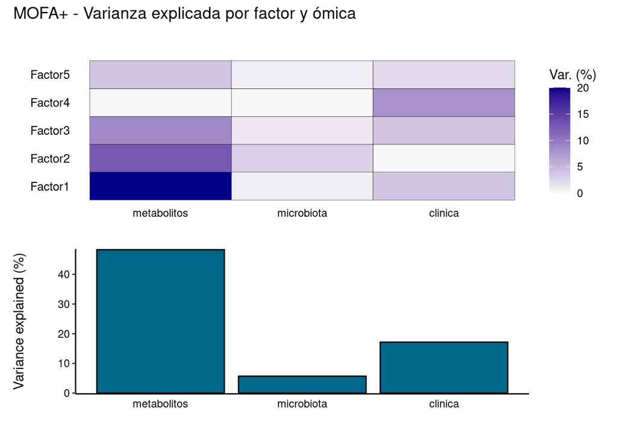

```r
# RESULTADOS MOFA+

# Varianza explicada por factor y por vista
library(patchwork)

lista_graficos <- plot_variance_explained(mofa, max_r2 = 20, plot_total = TRUE)

# Combinación de lista de gráficos generada por MOFA usando patchwork
(lista_graficos[[1]] / lista_graficos[[2]]) +
  plot_annotation(title = "MOFA+ - Varianza explicada por factor y ómica")
```

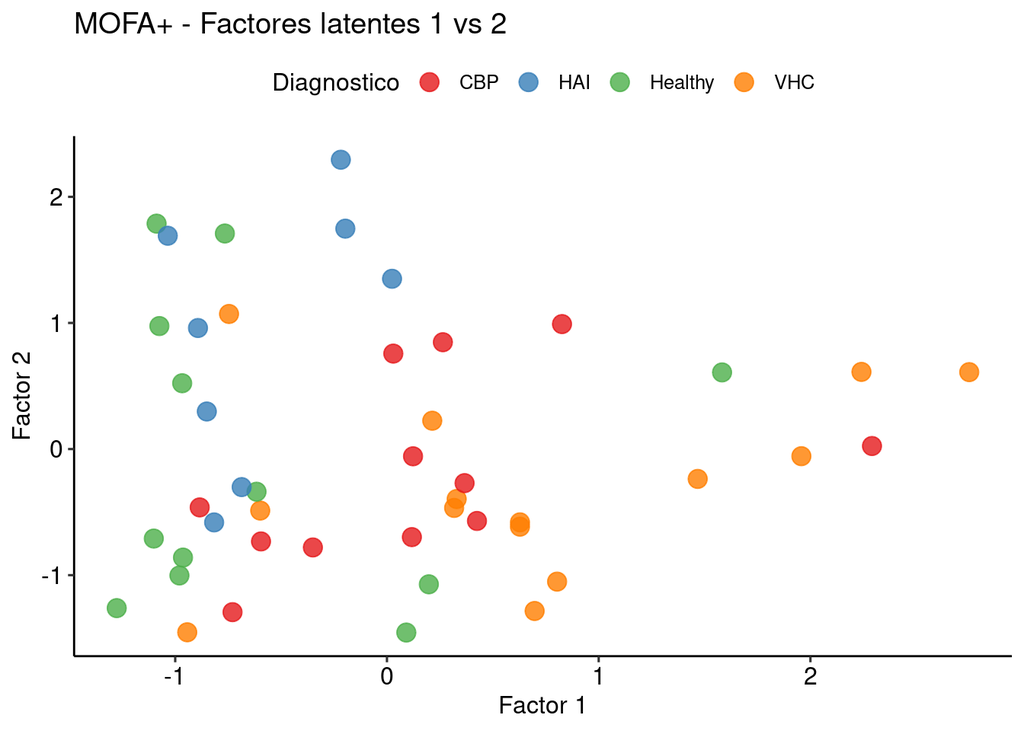

```r
# Extraer factores para plots manuales con paleta_dx
df_factores_plot <- get_factors(mofa)[[1]] %>%
  as.data.frame() %>%
  rownames_to_column("Sample") %>%
  left_join(
    data.frame(Sample = df_base$Sample,
               diagnostico = as.character(Y)),
    by = "Sample"
  )

# Factor 1 vs Factor 2
ggplot(df_factores_plot, aes(x = Factor1, y = Factor2, color = diagnostico)) +
  geom_point(size = 4, alpha = 0.8) +
  scale_color_manual(values = paleta_dx) +
  theme_pubr() +
  labs(title = "MOFA+ - Factores latentes 1 vs 2",
       x = "Factor 1", y = "Factor 2", color = "Diagnostico")
```

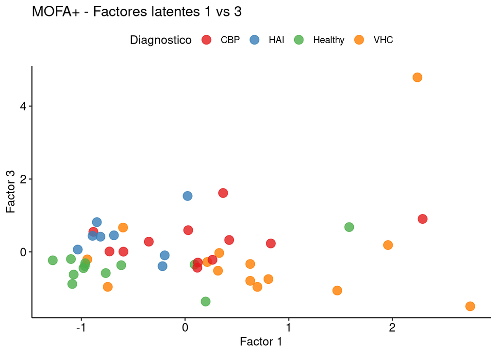

```r
# Factor 1 vs Factor 3
if (mofa@dimensions$K >= 3) {
  ggplot(df_factores_plot, aes(x = Factor1, y = Factor3, color = diagnostico)) +
    geom_point(size = 4, alpha = 0.8) +
    scale_color_manual(values = paleta_dx) +
    theme_pubr() +
    labs(title = "MOFA+ - Factores latentes 1 vs 3",
         x = "Factor 1", y = "Factor 3", color = "Diagnostico")
}
```

## Interpretación de factores y visualización de resultados MOFA+

Después del entrenamiento, se analizan los factores latentes obtenidos, evaluando la varianza explicada por cada uno y su relación con el diagnóstico clínico. Se generan visualizaciones de los factores en el espacio latente, así como gráficos de contribución de variables (weights) por cada ómica, identificando las características más influyentes en cada dimensión biológica.

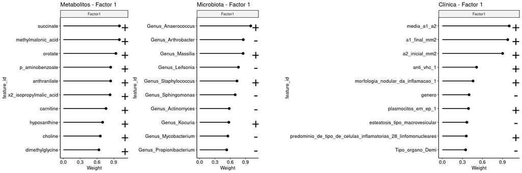

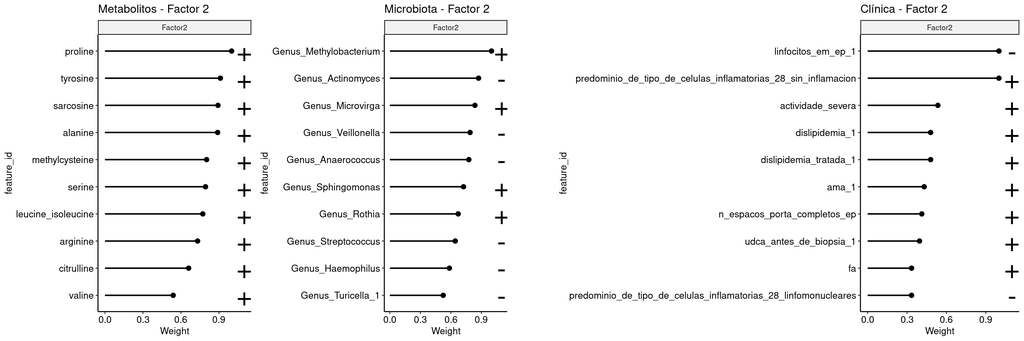

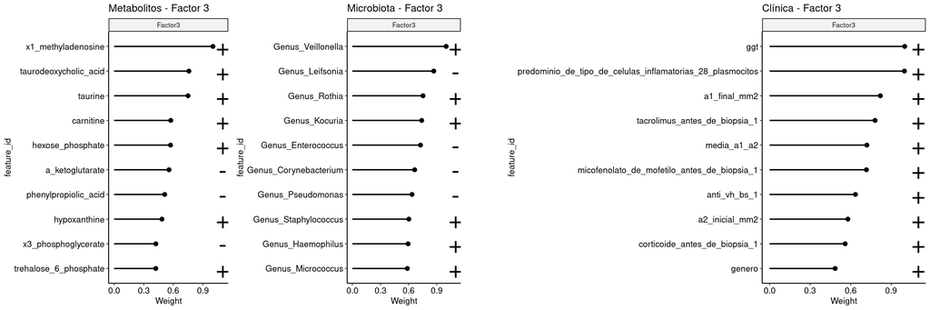

```r
# Top features por factor (3 primeros factores)
for (factor_n in 1:min(3, mofa@dimensions$K)) {

  p1 <- plot_top_weights(mofa, view = "metabolitos", factor = factor_n, nfeatures = 10, scale = TRUE) +
    theme_pubr(base_size = 10) + labs(title = paste0("Metabolitos - Factor ", factor_n))

  p2 <- plot_top_weights(mofa, view = "microbiota", factor = factor_n, nfeatures = 10, scale = TRUE) +
    theme_pubr(base_size = 10) + labs(title = paste0("Microbiota - Factor ", factor_n))

  p3 <- plot_top_weights(mofa, view = "clinica", factor = factor_n, nfeatures = 10, scale = TRUE) +
    theme_pubr(base_size = 10) + labs(title = paste0("Clínica - Factor ", factor_n)) +
    theme(plot.margin = margin(5, 5, 5, 50, "pt"))

  print(ggarrange(p1, p2, p3, ncol = 3, widths = c(1, 1, 2)))
}
```

```r
graphics.off()
```

Por otro lado, el **Factor 2** se centra de manera casi exclusiva en el metabolismo de aminoácidos (destacando *proline* y *tyrosine*) vinculados a un perfil microbiano específico (*Methylobacterium*) y a un estado clínico dominado por la severidad de la actividad inflamatoria con indicios de dislipidemia.

Finalmente, el **Factor 3** resalta marcadores de estrés o recambio celular (como *1-methyladenosine* y ácidos biliares conjugados como *taurodeoxycholic acid*), los cuales se alinean con la presencia de *Veillonella* a nivel de microbiota, una elevada actividad de la enzima hepática GGT (*ggt*) y un predominio plasmocitario.

En conjunto, los tres factores logran estratificar y conectar con claridad firmas moleculares concretas con perfiles de bacterias específicas y distintas manifestaciones histopatológicas y clínicas de los pacientes.

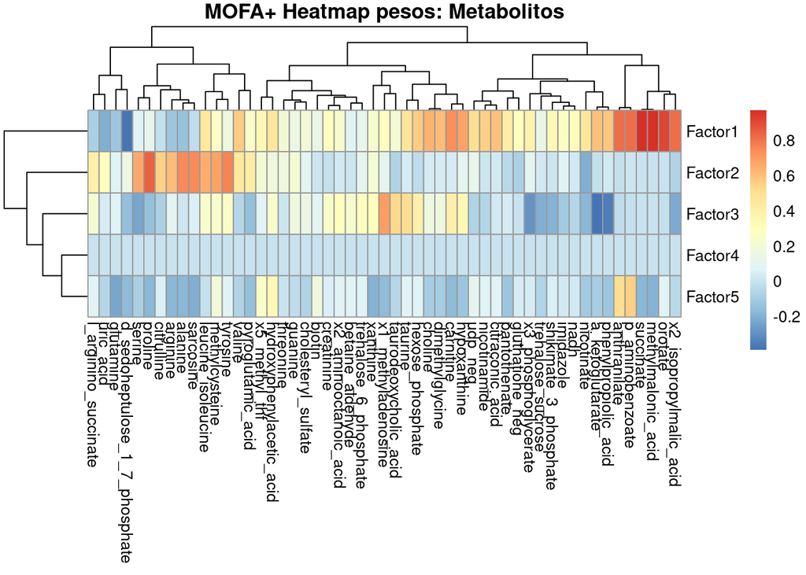

```r
# Heatmap de pesos por factor
plot_weights_heatmap(mofa, view = "metabolitos",
                     factors = 1:min(5, mofa@dimensions$K),
                     show_rownames = TRUE,
                     main = "MOFA+ Heatmap pesos: Metabolitos")
```

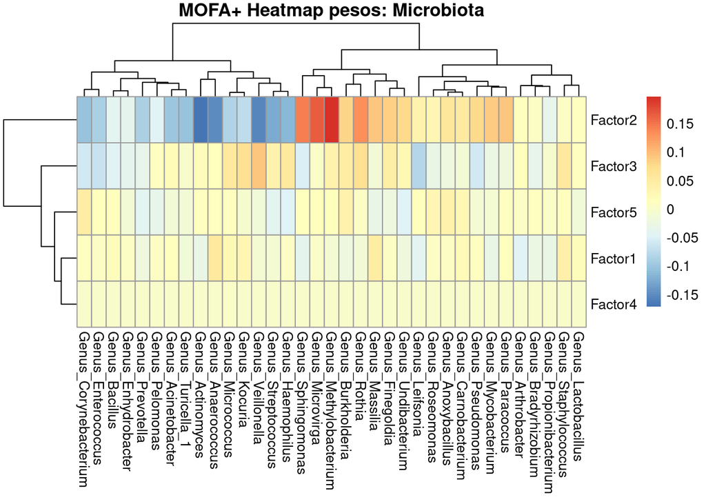

```r
plot_weights_heatmap(mofa, view = "microbiota",
                     factors = 1:min(5, mofa@dimensions$K),
                     show_rownames = TRUE,
                     main = "MOFA+ Heatmap pesos: Microbiota")
```

Estos mapas de calor de pesos (*heatmap plots* de *loadings*) para **metabolitos** y **microbiota** consolidan la jerarquía y el grado de influencia de las variables en los 5 factores latentes de MOFA+, mostrando de forma nítida la asimetría en la varianza explicada entre ambas ómicas. En la capa de metabolitos, se ratifica visualmente que el **Factor 1** ejerce el control dominante en la parte derecha del dendrograma con un bloque de pesos positivos muy altos para *succinate*, *methylmalonic_acid*, *orotate* y *x2_isopropylmalic_acid*, mientras que el **Factor 2** polariza de forma independiente el extremo izquierdo mediante la fuerte inducción de aminoácidos como *proline*, *tyrosine*, *sarcosine*, *alanine* y *leucine_isoleucine*. Por el contrario, el mapa de la microbiota exhibe un perfil de pesos notablemente más tenue y diluido (con una escala que apenas alcanza un máximo de 0.2 frente al 0.8 de los metabolitos), donde prácticamente toda la señal estructurada recae sobre el **Factor 2** —el cual dirige positivamente a géneros como *Microvirga*, *Methylobacterium* y *Sphingomonas*, y negativamente a *Actinomyces*, *Veillonella* y *Prevotella*—, mientras que los factores restantes, incluido el Factor 1, muestran perfiles planos y cercanos a cero. Este contraste molecular confirma que la variabilidad interindividual de la cohorte está fuertemente guiada por firmas metabólicas robustas y compartimentadas, dejando al microbioma como una capa de respuesta sutil, altamente variable y concentrada de forma casi exclusiva en el eje de la inflamación activa y la autoinmunidad (Factor 2).

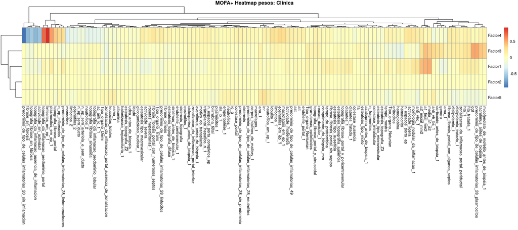

```r
# Pasamos el argumento 'margins' para que el paquete gráfico reserve espacio a la derecha (eje Y)
plot_weights_heatmap(mofa,
                     view = "clinica",
                     factors = 1:min(5, mofa@dimensions$K),
                     show_rownames = TRUE,
                     main = "MOFA+ Heatmap pesos: Clinica",
                     margins = c(5, 25))
```

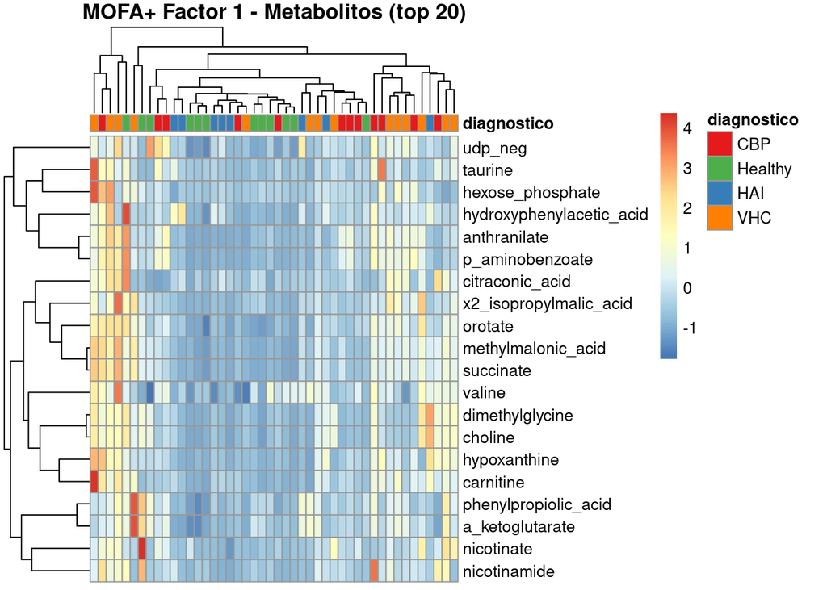

```r
# Heatmap de datos ordenados por Factor 1

metadatos_mofa <- samples_metadata(mofa)

# Si 'diagnostico' ya existe en los metadatos de MOFA, lo borramos antes de hacer el merge
# para evitar que R cree las molestas columnas 'diagnostico.x' y 'diagnostico.y'
if ("diagnostico" %in% colnames(metadatos_mofa)) {
  metadatos_mofa <- metadatos_mofa[, !colnames(metadatos_mofa) %in% "diagnostico", drop = FALSE]
}

df_diagnosticos <- df_base %>%
  dplyr::select(Sample, diagnostico_principal) %>%
  dplyr::rename(sample = Sample, diagnostico = diagnostico_principal)

# Combinamos de forma segura e insertamos de nuevo en el modelo
samples_metadata(mofa) <- merge(metadatos_mofa, df_diagnosticos, by = "sample", all.x = TRUE)

plot_data_heatmap(mofa, factor = 1, view = "metabolitos", features = 20,
                  show_rownames = TRUE, show_colnames = FALSE,
                  annotation_samples = "diagnostico",
                  annotation_colors  = list(diagnostico = paleta_dx),
                  main = "MOFA+ Factor 1 - Metabolitos (top 20)")
```

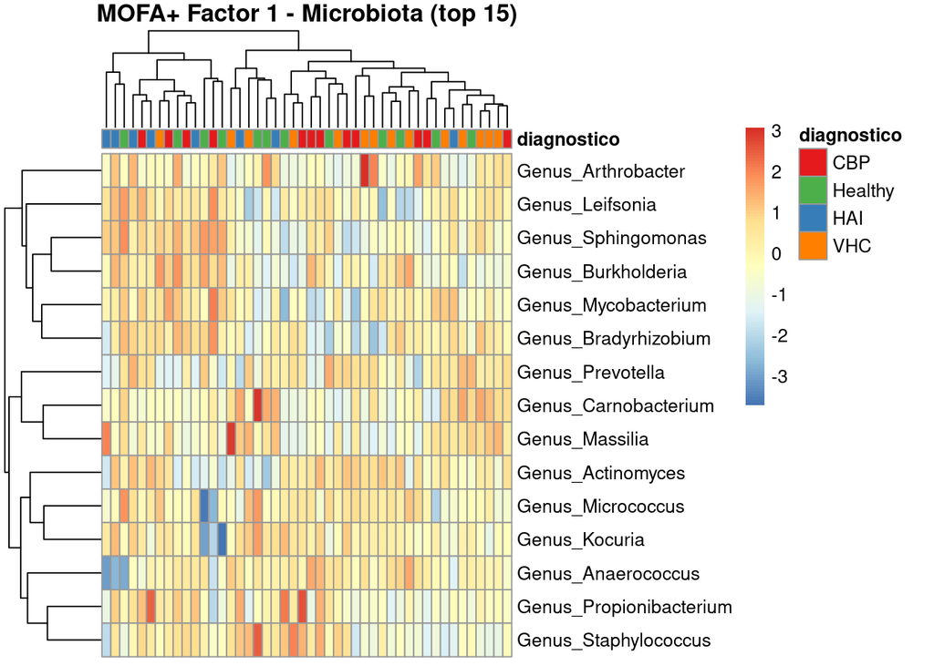

```r
plot_data_heatmap(mofa, factor = 1, view = "microbiota", features = 15,
                  show_rownames = TRUE, show_colnames = FALSE,
                  annotation_samples = "diagnostico",
                  annotation_colors  = list(diagnostico = paleta_dx),
                  main = "MOFA+ Factor 1 - Microbiota (top 15)")
```

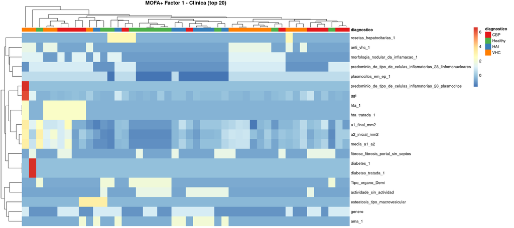

```r
plot_data_heatmap(mofa, factor = 1, view = "clinica", features = 20,
                  show_rownames = TRUE, show_colnames = FALSE,
                  annotation_samples = "diagnostico",
                  annotation_colors  = list(diagnostico = paleta_dx),
                  main = "MOFA+ Factor 1 - Clinica (top 20)")
```

## Evaluación estadística de asociación con diagnóstico

En este apartado se evalúa la relación entre los factores de MOFA+ y el diagnóstico mediante pruebas de Kruskal-Wallis. Los resultados permiten identificar qué factores están significativamente asociados a la enfermedad y respaldan su interpretación biológica, mostrando diferencias claras entre grupos clínicos.

```r
# Asociacion factores-diagnostico (Kruskal-Wallis)
n_factores <- mofa@dimensions$K
resultados_kw <- lapply(paste0("Factor", 1:n_factores), function(fac) {
  test <- kruskal.test(df_factores_plot[[fac]] ~ factor(df_factores_plot$diagnostico))
  data.frame(
    Factor   = fac,
    p_value  = round(test$p.value, 4),
    p_signif = case_when(
      test$p.value <= 0.001 ~ "***",
      test$p.value <= 0.01  ~ "**",
      test$p.value <= 0.05  ~ "*",
      TRUE                  ~ "ns"
    )
  )
}) %>% bind_rows()

print(resultados_kw %>% arrange(p_value))
```

```
##    Factor p_value p_signif
## 1 Factor1  0.0005      ***
## 2 Factor3  0.0023       **
## 3 Factor5  0.0566       ns
## 4 Factor2  0.0767       ns
## 5 Factor4  0.9159       ns
```

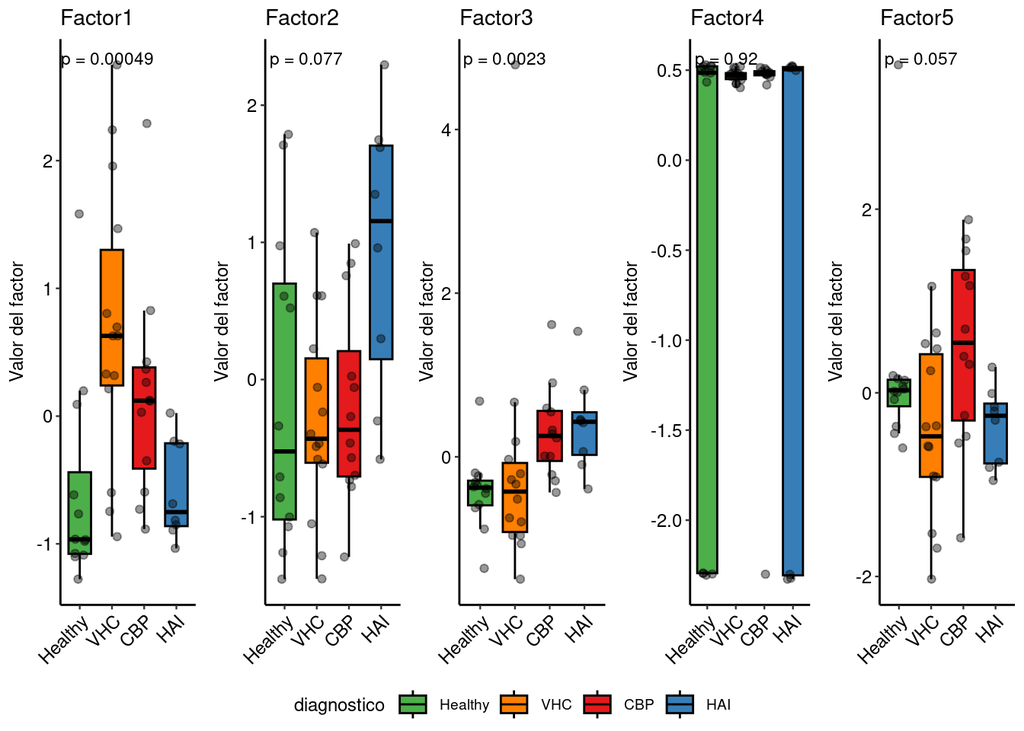

```r
# Boxplot factores por diagnostico
plots_factores <- lapply(paste0("Factor", 1:min(n_factores, 5)), function(fac) {
  ggboxplot(df_factores_plot, x = "diagnostico", y = fac,
            fill = "diagnostico", add = "jitter",
            add.params = list(alpha = 0.4, size = 1.5)) +
    scale_fill_manual(values = paleta_dx) +
    stat_compare_means(method = "kruskal.test", label = "p.format", size = 3) +
    theme_pubr(base_size = 9) +
    labs(title = fac, x = NULL, y = "Valor del factor") +
    theme(legend.position = "none",
          axis.text.x = element_text(angle = 45, hjust = 1))
})
ggarrange(plotlist = plots_factores, ncol = min(n_factores, 5), nrow = 1,
          common.legend = TRUE, legend = "bottom")
```

Los gráficos y Kruskal-Wallis muestran que los niveles de los factores latentes calculados difieren según el diagnóstico del paciente, identificando únicamente dos factores con diferencias estadísticamente significativas (alpha = 0.05). **Factor1 presenta la asociación más fuerte** (p = 0.0005), caracterizándose por valores elevados específicamente en el grupo con Hepatitis C (VHC). Por su parte, **Factor3 también muestra diferencias significativas** (p = 0.0023), con un incremento progresivo de sus valores en las patologías crónicas de tipo CBP y HAI en comparación con los controles sanos y el grupo VHC. En contraste, los **Factores 2, 4 y 5 no muestran variaciones significativas** entre los grupos diagnósticos (p > 0.05), destacando el comportamiento altamente disperso del Factor4, el cual no aporta valor discriminatorio para estas condiciones médicas.

# **Transición MOFA+ → DIABLO**

A partir de los factores significativos detectados en MOFA+, se plantea la necesidad de un enfoque supervisado. Esto motiva la aplicación de DIABLO, que permite identificar directamente las variables multi-ómicas que mejor discriminan entre los grupos clínicos.

# **Construcción del modelo DIABLO (integración SUPERVISADA)**

En esta fase se definen los bloques de datos (metabolitos, microbiota y clínica) y se configura la estructura del modelo supervisado. Se establece una matriz de diseño débilmente conectada para priorizar la capacidad predictiva sin forzar correlaciones artificiales entre ómicas

```r
# PREPARAR BLOQUES DIABLO
# NOTA: mat_clin incluye numéricas + categóricas codificadas, tras filtro NZV

X <- list(
  metabolitos = mat_met,
  microbiota  = mat_bact,
  clinica     = mat_clin
)

# Diseño débilmente conectado (0.1) para priorizar capacidad discriminativa evitando forzar correlaciones artificiales entre ómicas
design <- matrix(0.1, nrow = length(X), ncol = length(X),
                 dimnames = list(names(X), names(X)))
diag(design) <- 0

cat("Matriz de diseno DIABLO:\n")
```

```
## Matriz de diseno DIABLO:
```

```r
print(design)
```

```
##             metabolitos microbiota clinica
## metabolitos         0.0        0.1     0.1
## microbiota          0.1        0.0     0.1
## clinica             0.1        0.1     0.0
```

## Optimización y entrenamiento del modelo DIABLO

Después, se estima el número óptimo de componentes mediante validación cruzada y se ajustan los parámetros keepX para cada bloque. Con estos valores se entrena el modelo final DIABLO, optimizado para clasificación multiclase del diagnóstico clínico.

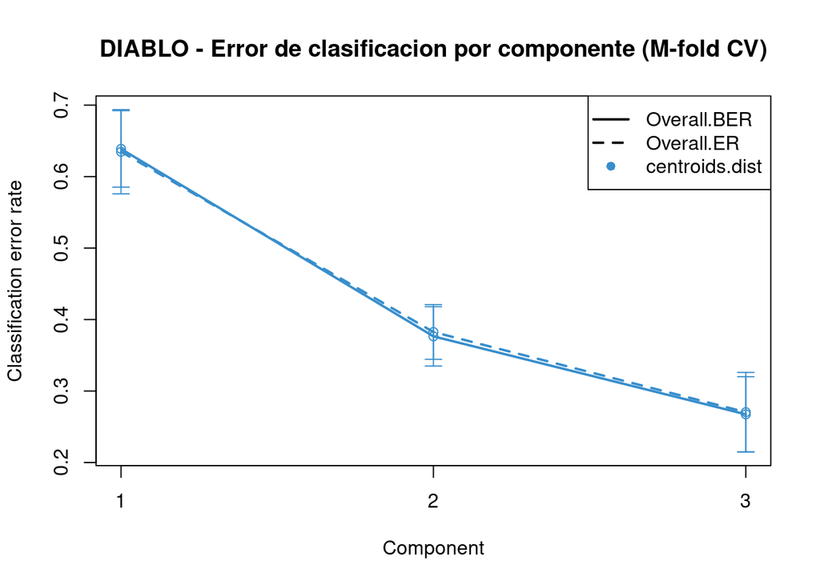

```r
# MODELO INICIAL - estimacion numero de componentes

# near.zero.var = TRUE para que DIABLO gestione las constantes en los folds
diablo_inicial <- block.plsda(X, Y, ncomp = 3, design = design, near.zero.var = TRUE)

perf_diablo <- perf(diablo_inicial, validation = "Mfold",
                    folds        = 3,
                    nrepeat      = 50,
                    progressBar  = FALSE,
                    dist         = "centroids.dist",
                    cpus         = 8)

plot(perf_diablo)
title("DIABLO - Error de clasificacion por componente (M-fold CV)")
```

```r
ncomp_opt <- perf_diablo$choice.ncomp$WeightedVote["Overall.BER", "centroids.dist"]
if (is.na(ncomp_opt) || ncomp_opt == 0) ncomp_opt <- 2
cat("ncomp optimo:", ncomp_opt, "\n")
```

```
## ncomp optimo: 3
```

Este gráfico muestra que el error de clasificación de DIABLO disminuye notablemente con cada componente añadido, pasando de un alto **0.64 (1 componente) a un óptimo de 0.27 (3 componentes)**. Dado que la tasa de error (tanto BER como ER) cae de forma constante y las barras de desviación se mantienen estables, **el modelo de 3 componentes es el más adecuado** para maximizar la precisión de la clasificación.

```r
# TUNING keepX: cuántas variables debe seleccionar de cada bloque ómico en cada componente del modelo

test_keepX <- list(
  metabolitos = c(5, 10, 15, 20),
  microbiota  = c(5, 10, 15),
  clinica     = c(5, 10, 15)
)

tune_diablo <- tune.block.splsda(
  X           = X,
  Y           = Y,
  ncomp       = ncomp_opt,
  test.keepX  = test_keepX,
  design      = design,
  validation  = "Mfold",
  folds       = 3,
  nrepeat     = 50,
  progressBar = FALSE,
  dist        = "centroids.dist",
  BPPARAM     = param_paralelo
)

cat("\nkeepX optimo por bloque:\n")
```

```
##
## keepX optimo por bloque:
```

```r
print(tune_diablo$choice.keepX)
```

```
## $metabolitos
## [1] 20 15  5
##
## $microbiota
## [1]  5 15 10
##
## $clinica
## [1] 10  5 15
```

```r
# MODELO FINAL DIABLO

diablo_final <- block.splsda(
  X      = X,
  Y      = Y,
  ncomp  = ncomp_opt,
  keepX  = tune_diablo$choice.keepX,
  design = design,
  near.zero.var = TRUE)

cat("Modelo DIABLO final ajustado.\n")
```

```
## Modelo DIABLO final ajustado.
```

## Visualizaciones Diablo

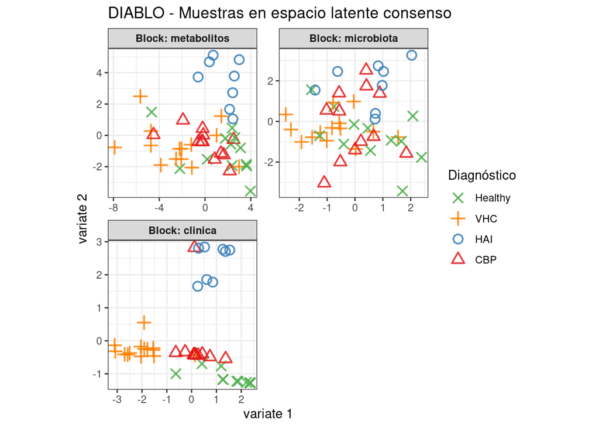

```r
# VISUALIZACIONES DIABLO

# Individuos en espacio latente consenso
# Extraer coordenadas de cada bloque
bloques <- c("metabolitos", "microbiota", "clinica")

df_plot <- do.call(rbind, lapply(bloques, function(b) {
  data.frame(
    x      = diablo_final$variates[[b]][, 1],
    y      = diablo_final$variates[[b]][, 2],
    grupo  = as.character(Y),
    bloque = b
  )
}))

df_plot$bloque <- factor(df_plot$bloque, levels = bloques)
df_plot$grupo  <- factor(df_plot$grupo,  levels = c("Healthy", "VHC", "HAI", "CBP"))

paleta_dx <- c(
  "Healthy" = "#4DAF4A",
  "VHC"     = "#FF7F00",
  "HAI"     = "#377EB8",
  "CBP"     = "#E41A1C"
)

simbolos <- c("Healthy" = 4, "VHC" = 3, "HAI" = 1, "CBP" = 2)

ggplot(df_plot, aes(x = x, y = y, color = grupo, shape = grupo)) +
  geom_point(size = 3, stroke= 1.0, alpha = 0.85) +
  facet_wrap(~ bloque, ncol = 2, scales = "free",
             labeller = labeller(bloque = c(
               metabolitos = "Block: metabolitos",
               microbiota  = "Block: microbiota",
               clinica     = "Block: clinica"
             ))) +
  scale_color_manual(name = "Diagnóstico", values = paleta_dx) +
  scale_shape_manual(name = "Diagnóstico", values = simbolos) +
  theme_bw() +
  labs(
    title = "DIABLO - Muestras en espacio latente consenso",
    x     = "variate 1",
    y     = "variate 2"
  ) +
  theme(
    legend.position  = "right",
    strip.background = element_rect(fill = "grey85"),
    strip.text       = element_text(face = "bold"),
    aspect.ratio     = 1   # fuerza paneles cuadrados
  )
```

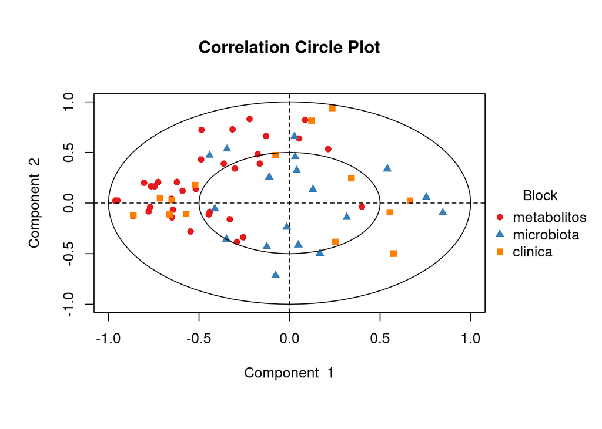

```r
# Variables (correlacion con componentes)
plotVar(diablo_final,
        var.names = list(FALSE, FALSE, FALSE),
        style     = "graphics",
        legend    = TRUE,
        pch       = c(16, 17, 15),
        col       = c("#E41A1C", "#377EB8", "#FF7F00"))
```

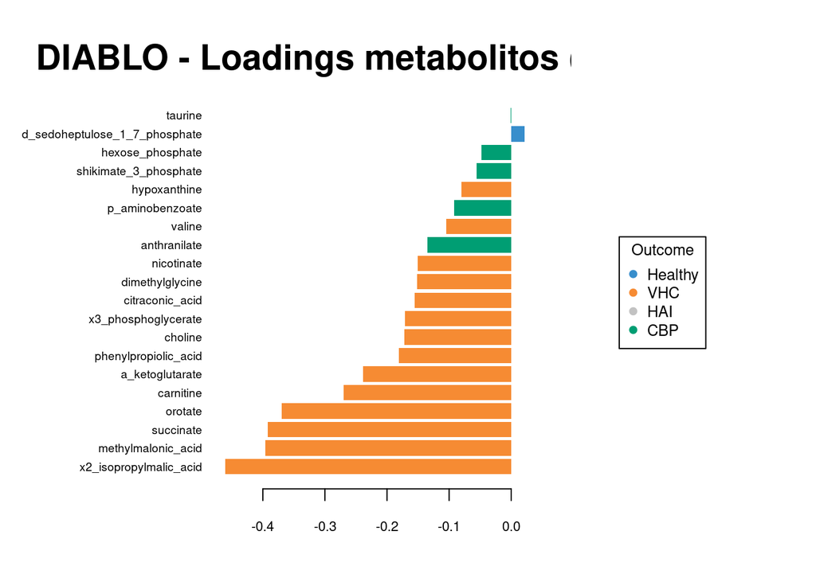

```r
# Loadings componente 1
plotLoadings(diablo_final, comp = 1, block = "metabolitos",
             contrib = "max", method = "median", size.name = 0.6,
             title = "DIABLO - Loadings metabolitos (comp 1)")
```

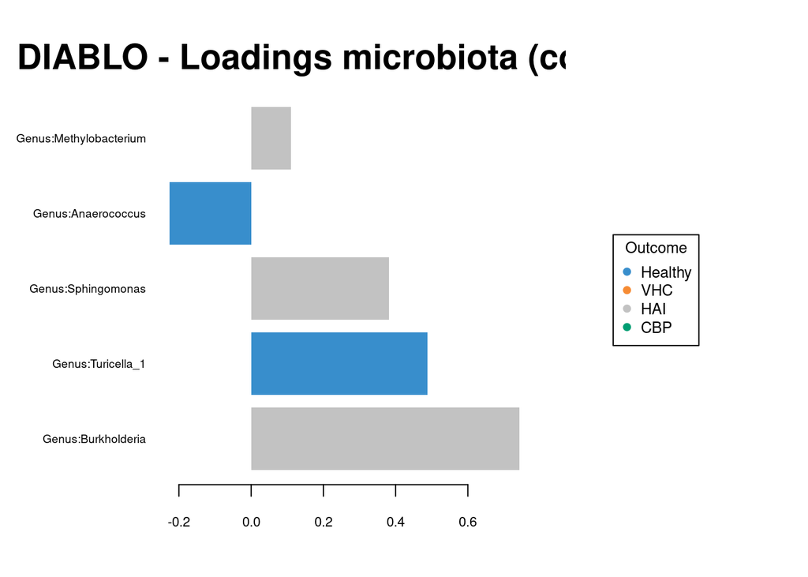

```r
plotLoadings(diablo_final, comp = 1, block = "microbiota",
             contrib = "max", method = "median", size.name = 0.6,
             title = "DIABLO - Loadings microbiota (comp 1)")
```

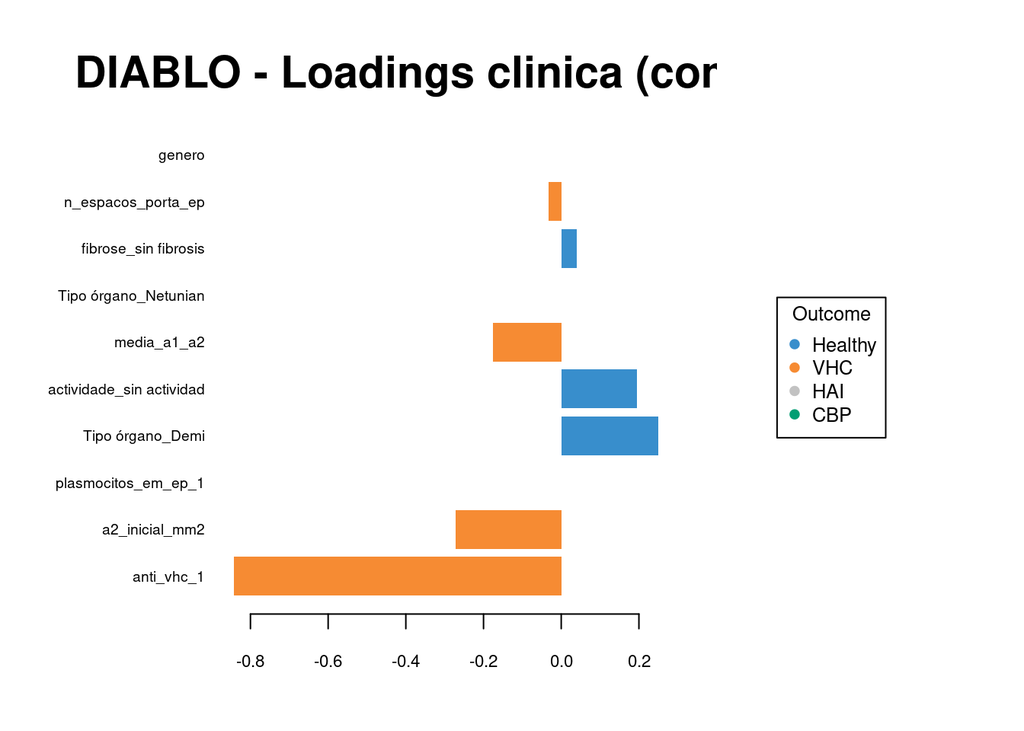

```r
plotLoadings(diablo_final, comp = 1, block = "clinica",
             contrib = "max", method = "median", size.name = 0.6,
             title = "DIABLO - Loadings clinica (comp 1)")
```

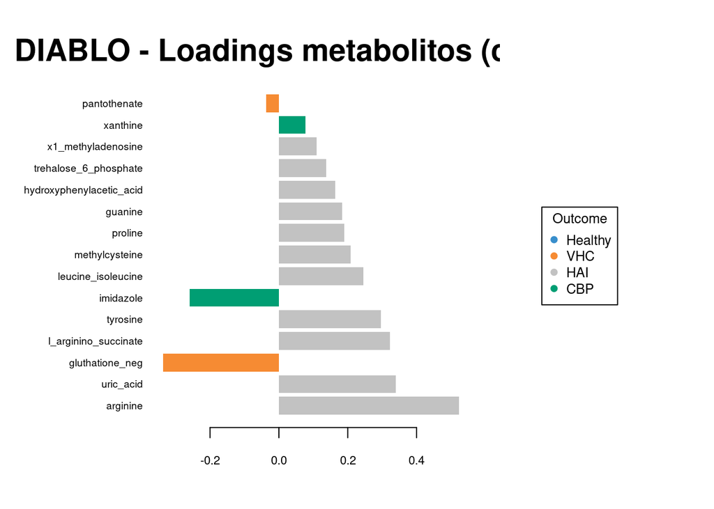

```r
# Loadings componente 2
plotLoadings(diablo_final, comp = 2, block = "metabolitos",
             contrib = "max", method = "median", size.name = 0.6,
             title = "DIABLO - Loadings metabolitos (comp 2)")
```

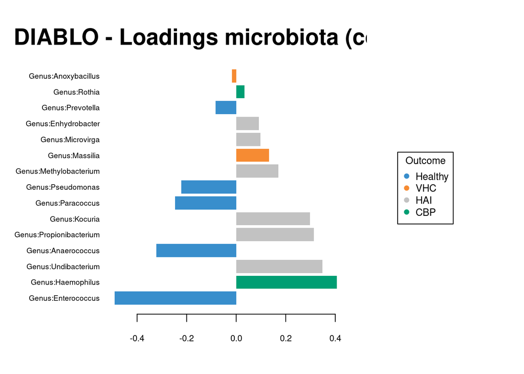

```r
plotLoadings(diablo_final, comp = 2, block = "microbiota",
             contrib = "max", method = "median", size.name = 0.6,
             title = "DIABLO - Loadings microbiota (comp 2)")
```

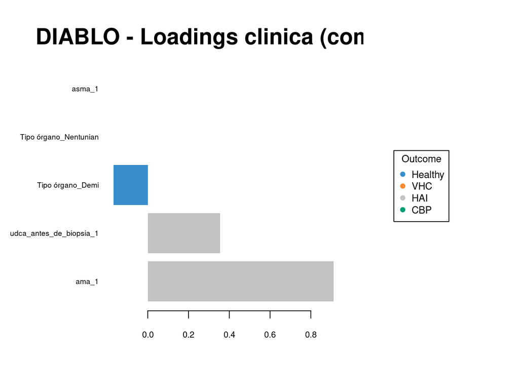

```r
plotLoadings(diablo_final, comp = 2, block = "clinica",
             contrib = "max", method = "median", size.name = 0.6,
             title = "DIABLO - Loadings clinica (comp 2)")
```

```r
# Clustered Image Map
png("DIABLO_CIM.png", width = 4000, height = 3000, res = 350)
cimDiablo(diablo_final,
          comp        = 1:min(2, ncomp_opt),
          title       = "DIABLO - Correlaciones entre variables",
          margins     = c(12, 12),
          size.legend = 0.7)
```

```
##
## trimming values to [-3, 3] range for cim visualisation. See 'trim' arg in ?cimDiablo
```

```r
dev.off()
```

```r
graphics.off()

# Red de correlaciones entre omicas
png("DIABLO_Red_Correlaciones.png", width = 2500, height = 2500, res = 250)
network(diablo_final,
        blocks         = c("metabolitos", "microbiota", "clinica"),
        comp           = list(metabolitos = c(1, 2),
                              microbiota  = c(1, 2),
                              clinica     = c(1, 2)),
        color.node     = c("#E41A1C", "#377EB8", "#FF7F00"),
        shape.node     = c("rectangle", "circle", "rectangle"),
        cutoff         = 0.6,
        color.edge     = mixOmics::color.GreenRed(50),
        cex.node       = 0.6,
        cex.edge.label = 0.7,
        lwd.edge       = 1)
title("DIABLO - Red de relevancia multiomica (|r| > 0.6)", cex.main = 1.2)
dev.off()
```

```r
graphics.off()

# Circos plot
lista_nombres_variables <- list(
  metabolitos = colnames(mat_met),
  microbiota  = colnames(mat_bact),
  clinica     = colnames(mat_clin)
)

png("DIABLO_CircosPlot.png", width = 3000, height = 3000, res = 450)
circosPlot(object        = diablo_final,
           comp          = c(1, 2),
           cutoff        = 0.6,
           color.blocks  = c("#E41A1C", "#377EB8", "#FF7F00"),
           color.cor     = c("#4DAF4A", "#E41A1C"),
           var.names     = lista_nombres_variables,
           cex.key       = 0.6,
           cex.label     = 0.8,
           show.IntLines = TRUE,
           line          = TRUE)
title("DIABLO - Circos (|r| > 0.6)", cex.main = 1.0)
dev.off()
```

```r
graphics.off()
```

## Evaluación del rendimiento del modelo DIABLO

En este apartado se evalúa el rendimiento del modelo mediante tasas de error, exactitud global y matrices de confusión. Además, se analiza el desempeño por clase clínica, permitiendo identificar qué diagnósticos son más fácilmente separables.

```r
# EVALUACION FINAL DIABLO

perf_final <- perf(diablo_final,
                   validation  = "Mfold",
                   folds       = 3,
                   nrepeat     = 50,
                   progressBar = FALSE,
                   cpus        = 8)

# Tasa de error por componente
cat("\n=== TASA DE ERROR POR COMPONENTE (centroids.dist) ===\n")
```

```
##
## === TASA DE ERROR POR COMPONENTE (centroids.dist) ===
```

```r
print(round(perf_final$WeightedVote.error.rate$centroids.dist, 3))
```

```
##             comp1 comp2 comp3
## Healthy     0.350 0.270 0.210
## VHC         0.260 0.177 0.060
## HAI         0.475 0.085 0.100
## CBP         0.517 0.353 0.270
## Overall.ER  0.388 0.231 0.161
## Overall.BER 0.400 0.221 0.160
```

```r
ber_por_comp <- perf_final$WeightedVote.error.rate$centroids.dist["Overall.BER", ]
mejor_comp_n <- which.min(ber_por_comp)
cat("\nMejor componente:", names(mejor_comp_n),
    "| BER =",    round(ber_por_comp[mejor_comp_n], 3),
    "| Acierto =", round(1 - ber_por_comp[mejor_comp_n], 3), "\n")
```

```
##
## Mejor componente: comp3 | BER = 0.16 | Acierto = 0.84
```

```r
# Tasa de acierto por clase en el componente optimo
cat("\n=== TASA DE ACIERTO POR CLASE (comp", ncomp_opt, ", centroids.dist) ===\n")
```

```
##
## === TASA DE ACIERTO POR CLASE (comp 3 , centroids.dist) ===
```

```r
error_por_clase <- perf_final$WeightedVote.error.rate$centroids.dist[
  c("Healthy", "VHC", "HAI", "CBP"),
  paste0("comp", ncomp_opt)
]
acierto_por_clase <- round(1 - error_por_clase, 3)
print(acierto_por_clase)
```

```
## Healthy     VHC     HAI     CBP
##    0.79    0.94    0.90    0.73
```

```r
# Matriz de confusion desde $class
dist_usar   <- "centroids.dist"
col_usar    <- ncomp_opt
bloque_usar <- "metabolitos"
n_rep       <- length(perf_final$class)

pred_matrix <- do.call(cbind, lapply(seq_len(n_rep), function(r) {
  rep_name <- paste0("nrep", r)
  mat <- perf_final$class[[rep_name]][[bloque_usar]][[dist_usar]]
  mat[, col_usar]
}))

sample_names <- rownames(perf_final$class$nrep1[[bloque_usar]][[dist_usar]])

pred_moda <- apply(pred_matrix, 1, function(x) {
  tab <- table(x)
  names(tab)[which.max(tab)]
})

Y_alineado <- Y[sample_names]

conf_mat <- table(
  Predicho = factor(pred_moda,  levels = levels(Y)),
  Real     = factor(Y_alineado, levels = levels(Y))
)

cat("\n=== MATRIZ DE CONFUSION (centroids.dist, comp", ncomp_opt,
    ", moda sobre", n_rep, "reps) ===\n")
```

```
##
## === MATRIZ DE CONFUSION (centroids.dist, comp 3 , moda sobre 50 reps) ===
```

```r
print(conf_mat)
```

```
##          Real
## Predicho  Healthy VHC HAI CBP
##   Healthy      10   1   0   5
##   VHC           1  11   1   0
##   HAI           0   0   7   1
##   CBP           1   2   0   6
```

```r
acierto_global <- round(sum(diag(conf_mat)) / sum(conf_mat), 3)
cat("\nAcierto global:", acierto_global,
    "| Error global:", round(1 - acierto_global, 3), "\n")
```

```
##
## Acierto global: 0.739 | Error global: 0.261
```

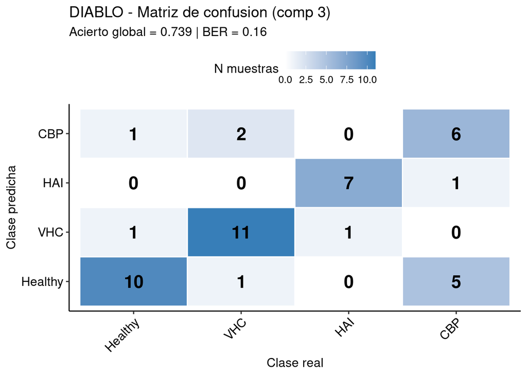

```r
# Heatmap de la matriz de confusion
df_conf <- as.data.frame(conf_mat)

ggplot(df_conf, aes(x = Real, y = Predicho, fill = Freq)) +
  geom_tile(color = "white", linewidth = 0.5) +
  geom_text(aes(label = Freq), size = 6, fontface = "bold") +
  scale_fill_gradient(low = "white", high = "#377EB8") +
  theme_pubr() +
  labs(title    = paste0("DIABLO - Matriz de confusion (comp ", ncomp_opt, ")"),
       subtitle = paste0("Acierto global = ", acierto_global,
                         " | BER = ", round(ber_por_comp[mejor_comp_n], 3)),
       x    = "Clase real",
       y    = "Clase predicha",
       fill = "N muestras") +
  theme(axis.text.x = element_text(angle = 45, hjust = 1))
```

El análisis de rendimiento del modelo revela una clara reducción de la tasa de error global a medida que se añaden componentes latentes, consolidando a la **componente 3 (`comp3`)** como la óptima, al registrar la tasa de error balanceado más baja (**BER = 0.160**) y una robusta precisión global de acierto del **84%**. Al evaluar el comportamiento por clases diagnósticas en este componente óptimo, junto con la información resultante de la matriz de distancias logrando un acierto global del 73.9%, se observa una alta capacidad discriminatoria para identificar a los pacientes con Hepatitis C (**VHC: 94% de acierto; 11 clasificados correctamente**) y Hepatitis Autoinmune (**HAI: 90% de acierto; 7 correctamente clasificados**). Por el contrario, el punto débil del clasificador se encuentra en la distinción entre **Healthy** y **CBP**, donde se observa una confusión cruzada: 5 muestras de CBP fueron clasificadas erróneamente como Healthy (79% de acierto), y 6 muestras reales de CBP se asignaron correctamente pero con un margen estrecho frente al error, lo que sitúa a CBP como la clase con menor tasa de acierto (73%).

# **Interpretación de biomarcadores seleccionados**

Después, se extraen las variables más relevantes de cada ómica según su contribución al modelo DIABLO. Esto permite identificar posibles biomarcadores clínicos, metabólicos y microbianos asociados a la clasificación de los pacientes.

```r
# VARIABLES SELECCIONADAS Y EXPORTACION DE BIOMARCADORES

for (bloque in names(X)) {
  cat("\n============================\n")
  cat("BLOQUE:", bloque, "\n")
  cat("============================\n")
  sel <- selectVar(diablo_final, block = bloque, comp = 1)
  print(head(sel[[bloque]]$value, 10))
}
```

```
##
## ============================
## BLOQUE: metabolitos
## ============================
##                         value.var
## x2_isopropylmalic_acid -0.4603374
## methylmalonic_acid     -0.3964041
## succinate              -0.3922945
## orotate                -0.3695677
## carnitine              -0.2694553
## a_ketoglutarate        -0.2380909
## phenylpropiolic_acid   -0.1804636
## choline                -0.1721964
## x3_phosphoglycerate    -0.1715453
## citraconic_acid        -0.1555662
##
## ============================
## BLOQUE: microbiota
## ============================
##                         value.var
## Genus:Burkholderia      0.7426960
## Genus:Turicella_1       0.4886839
## Genus:Sphingomonas      0.3820932
## Genus:Anaerococcus     -0.2265719
## Genus:Methylobacterium  0.1107280
##
## ============================
## BLOQUE: clinica
## ============================
##                             value.var
## anti_vhc_1               -0.842197655
## a2_inicial_mm2           -0.272315847
## plasmocitos_em_ep_1      -0.252165155
## Tipo órgano_Demi          0.249861769
## actividade_sin actividad  0.194345441
## media_a1_a2              -0.175593314
## Tipo órgano_Netunian     -0.138313700
## fibrose_sin fibrosis      0.040771583
## n_espacos_porta_ep       -0.032594477
## genero                    0.008393812
```

```r
lista_biom <- lapply(names(X), function(bloque) {
  sel <- selectVar(diablo_final, block = bloque, comp = 1)
  data.frame(
    variable    = rownames(sel[[bloque]]$value),
    loading     = sel[[bloque]]$value[, 1],
    abs_loading = abs(sel[[bloque]]$value[, 1]),
    block       = bloque
  ) %>% arrange(desc(abs_loading))
})
names(lista_biom) <- names(X)

tabla_biomarcadores <- bind_rows(lista_biom)
```

Estas tablas muestran los vectores de carga (*loadings*) de las variables seleccionadas por el modelo DIABLO en el **componente 1** para tres bloques de datos (metabolómica, microbioma y variables clínicas/histológicas), ordenadas según su contribución a la firma molecular común.

# **Concordancia entre MOFA+ y DIABLO**

En este punto se compara la estructura latente obtenida por MOFA+ con el componente supervisado principal de DIABLO. La correlación entre ambos modelos permite evaluar si están capturando el mismo eje biológico subyacente.

```r
# CONCORDANCIA INTER-MODELO: MOFA+ vs DIABLO

comp_diablo <- diablo_final$variates$metabolitos[, 1, drop = FALSE] %>%
  as.data.frame() %>%
  rownames_to_column("Sample") %>%
  setNames(c("Sample", "DIABLO_Comp1"))

df_inter_modelos <- df_factores_plot %>%
  left_join(comp_diablo, by = "Sample")

test_corr <- cor.test(df_inter_modelos$Factor1,
                      df_inter_modelos$DIABLO_Comp1,
                      method = "spearman")

cat("\n=== Concordancia inter-modelo (MOFA+ Factor1 ~ DIABLO Comp1) ===\n")
```

```
##
## === Concordancia inter-modelo (MOFA+ Factor1 ~ DIABLO Comp1) ===
```

```r
cat("  Spearman r =", round(test_corr$estimate, 3),
    " p =", round(test_corr$p.value, 4), "\n")
```

```
##   Spearman r = -0.965  p = 0
```

```r
cat("  Si |r| > 0.5 y p < 0.05, ambos metodos capturan el mismo eje biologico\n")
```

```
##   Si |r| > 0.5 y p < 0.05, ambos metodos capturan el mismo eje biologico
```

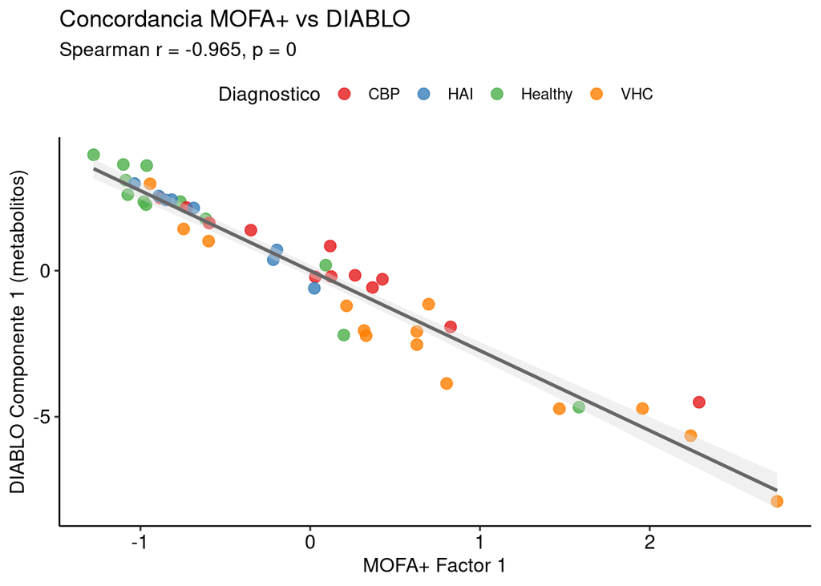

```r
ggplot(df_inter_modelos, aes(x = Factor1, y = DIABLO_Comp1, color = diagnostico)) +
  geom_point(size = 3, alpha = 0.8) +
  geom_smooth(method = "lm", color = "gray40", se = TRUE, fill = "gray85") +
  scale_color_manual(values = paleta_dx) +
  theme_pubr() +
  labs(title    = "Concordancia MOFA+ vs DIABLO",
       subtitle = paste0("Spearman r = ", round(test_corr$estimate, 3),
                         ", p = ", round(test_corr$p.value, 4)),
       x        = "MOFA+ Factor 1",
       y        = "DIABLO Componente 1 (metabolitos)",
       color    = "Diagnostico")
```

Este gráfico demuestra una **concordancia biológica casi perfecta** entre ambos enfoques multi-ómicos, revelando una correlación de Spearman de **r = -0.965 (p = 0)** entre el Factor 1 de MOFA+ y el Componente 1 de DIABLO. La alineación lineal confirma que ambos métodos capturan exactamente el mismo eje de variación biológica latente (pero con signos inversos), mostrando además una separación clínica coherente: los pacientes sanos e histológicamente estables (**Healthy** y **HAI**) se agrupan de forma compacta en el extremo superior izquierdo, mientras que los perfiles patológicos (**CBP** y **VHC**) se desplazan progresivamente hacia la derecha de la gráfica.

# **Integración final entre metaboloma y microbiota**

Finalmente, se analizan las correlaciones cruzadas entre los biomarcadores más relevantes seleccionados por DIABLO. Se construye un heatmap inter-ómico que permite visualizar las relaciones entre metabolitos y taxones bacterianos, revelando posibles interacciones biológicas clave.

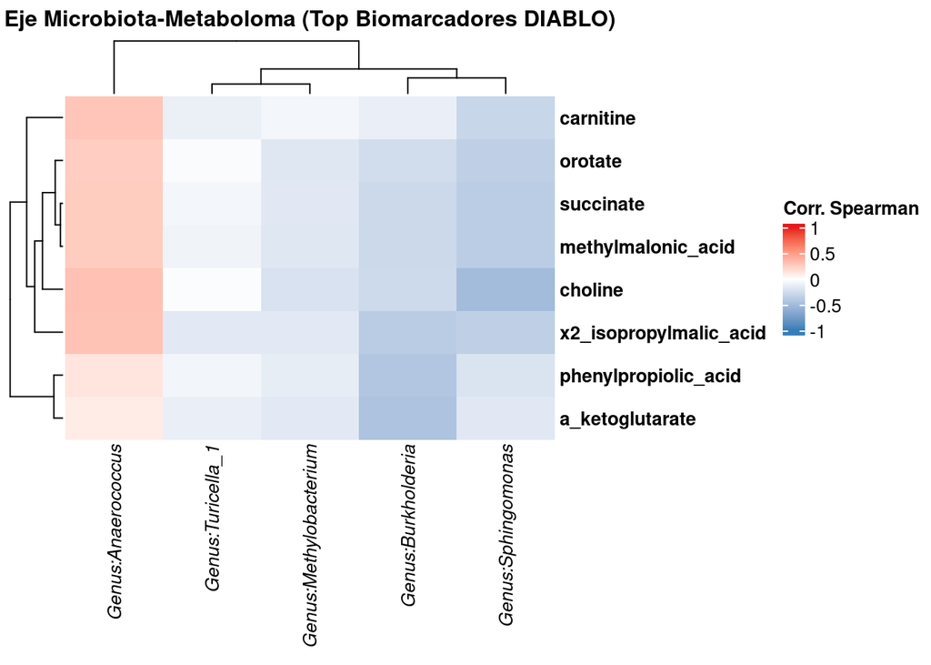

```r
#HEATMAP DE CORRELACION INTER-OMICA (top biomarcadores DIABLO)

top_metabolitos <- tabla_biomarcadores %>%
  dplyr::filter(block == "metabolitos") %>%
  slice_max(abs_loading, n = 8) %>%
  pull(variable)

top_microbiota <- tabla_biomarcadores %>%
  dplyr::filter(block == "microbiota") %>%
  slice_max(abs_loading, n = 8) %>%
  pull(variable)

sub_mat_met  <- mat_met[, top_metabolitos, drop = FALSE]
sub_mat_bact <- mat_bact[, top_microbiota, drop = FALSE]

mat_corr_cruzada <- cor(sub_mat_met, sub_mat_bact, method = "spearman")

col_fun <- colorRamp2(c(-1, 0, 1), c("#377EB8", "white", "#E41A1C"))

heatmap_inter_omica <- Heatmap(
  mat_corr_cruzada,
  name             = "Corr. Spearman",
  col              = col_fun,
  cluster_rows     = TRUE,
  cluster_columns  = TRUE,
  show_row_dend    = TRUE,
  show_column_dend = TRUE,
  row_names_gp     = gpar(fontface = "bold", fontsize = 10),
  column_names_gp  = gpar(fontface = "italic", fontsize = 10),
  column_title     = "Eje Microbiota-Metaboloma (Top Biomarcadores DIABLO)",
  column_title_gp  = gpar(fontsize = 12, fontface = "bold"),
  heatmap_legend_param = list(direction = "vertical")
)

draw(heatmap_inter_omica)
```

Este mapa de calor (*heatmap*) revela una **clara estructura dicotómica en la interacción microbiota-metaboloma** basada en las correlaciones de Spearman de los top biomarcadores seleccionados por DIABLO. El clúster bacteriano se divide drásticamente en dos perfiles: por un lado, el género *Anaerococcus* muestra una **correlación positiva generalizada** con todo el bloque de metabolitos, destacando su vínculo con la *carnitine* y la *choline*; por otro lado, los géneros *Turicella_1*, *Methylobacterium*, *Burkholderia* y *Sphingomonas* exhiben una **correlación negativa consistente** con estos mismos compuestos. Este comportamiento inverso y perfectamente agrupado por la dendrografía superior sugiere la existencia de un eje funcional coordinado, donde el aumento de ciertos géneros bacterianos coincide sistemáticamente con la depleción de metabolitos clave como el *succinato* o el *alfa-cetoglutarato*, reflejando una firma co-regulada en el ecosistema intestinal.